# Coronavirus Analysis in the United States

Non Nonceeya, Nicholas Guan, Angela Pandit

5/17/2020

## 1. Introduction

In the last couple months, the United States and many countries around the world have locked down and heavily restricted social gatherings in efforts to prevent the spread of SARS-CoV2, more commonly referred to as COVID-19. With the world essentially in lock down, it seems as though every news outlet is reporting about COVID-19. However, with the increasing articles about the virus and its effects, the amount of false information is increasing as well. As of now, most media outlets are calculating the CMR (crude mortality rate) by dividing the total cases by the deaths. However, the more true calculation of mortality from COVID-19 is (deaths + recovered)/(total cases). With this method, a more accurate mortality can be precieved and can be used to visulalize a more accurate infection curve.

## 3, Libraries

As we continue with this analysis, we want to take advantage of many powerful R libraries.

```r
library(tidyr)
library(ggplot2)
library(broom)
library(caret)
library(tidyverse)
library(lubridate)
library(readr)
library(stringr)
```

## 4. Getting started with the Data

Dataset can be found at: https://www.kaggle.com/ashudata/covid19dataset

There are **2** datasets available but for this analysis we have chosen the **COVID_Data_Basic** dataset

The data is fetched from John Hopkins University & European Centre for Disease Prevention and Control (ECDC), processed, and available in a CSV format. Also note that these sources are considered to be credible.

List of attributes in this dataset:

- Country: Affected Country
- Date: Date of observation (YYYY-MM-DD)
- Confirmed: Cumulative # of confirmed cases
- Death: Cumulative # of death cases
- Recovered: Cumulative # of recovered cases
- newConfirmed: # of new confirmed cases/day
- newDeath: # of new death cases/day
- newRecovered: # of new recovered cases/day

First, let’s take a look at the various rows that we have available in our dataset. As we can see, this dataset contains useful global Coronavirus data that we can use for analysis. Fortunately for us, the fields for our columns are appropiate for data analysis and we do not need to further **tidy** our data. Our countries are readily available as **Character vectors**, Date as **Dates**, and cases as **Doubles**.

```r
covid_data <- read_csv("COVID_Data_Basic.csv")
sample_n(covid_data, 10)
```

```
## # A tibble: 10 x 9
##       X1 Country Date       Confirmed Death Recovered newConfirmed newDeath
##    <dbl> <chr>   <date>         <dbl> <dbl>     <dbl>        <dbl>    <dbl>
##  1  9299 Sweden  2020-03-16      1103     6         1           81        3
##  2  9995 United~ 2020-01-24         0     0         0            0        0
##  3  2222 Congo ~ 2020-02-12         0     0         0            0        0
##  4  7110 Nicara~ 2020-02-20         0     0         0            0        0
##  5  8551 Serbia  2020-02-23         0     0         0            0        0
##  6  8758 Slovak~ 2020-03-05         0     0         0            0        0
##  7 10338 Vietnam 2020-02-02         6     0         1            0        0
##  8 65810 Antigu~ 2020-04-08        19     2         0            0        1
##  9 65701 Eritrea 2020-04-04        29     0         0            7        0
## 10  6899 Nepal   2020-02-27         1     0         1            0        0
## # ... with 1 more variable: newRecovered <dbl>
```

Our goal is to analyze the COVID-19 situation in the United States so we would then use **filter** from the **dplyr** library to obtain just the United State data (labeled US).

```r
US_data <- filter(covid_data, Country == "US")

head(US_data, 10)
```

```
## # A tibble: 10 x 9
##       X1 Country Date       Confirmed Death Recovered newConfirmed newDeath
##    <dbl> <chr>   <date>         <dbl> <dbl>     <dbl>        <dbl>    <dbl>
##  1 10109 US      2019-12-31         0     0         0            0        0
##  2 10110 US      2020-01-01         0     0         0            0        0
##  3 10111 US      2020-01-02         0     0         0            0        0
##  4 10112 US      2020-01-03         0     0         0            0        0
##  5 10113 US      2020-01-04         0     0         0            0        0
##  6 10114 US      2020-01-05         0     0         0            0        0
##  7 10115 US      2020-01-06         0     0         0            0        0
##  8 10116 US      2020-01-07         0     0         0            0        0
##  9 10117 US      2020-01-08         0     0         0            0        0
## 10 10118 US      2020-01-09         0     0         0            0        0
## # ... with 1 more variable: newRecovered <dbl>
```

## 5. Exploratory Data Analysis

### Data Visualization

First, let’s display a graph of the cumulative confirmed, death, and recovered cases to get a sense of the spread of the virus. In order to do this, we are going to take advantage of the powerful **ggplot** library. In addition to the cumulative cases, we will also graph the newConfirmed, newDeath, and newRecovered columns in another graph. The additional columns indicate the amount of cases on a given day and will assist us in further analysis.

A few things to consider about these graphs is the spread and central tendencies. We can see from these graphs that the confirmed cases and deaths have peaked (max) in late April/early May. The cases per day have followed a very linear pattern until early April when it starts to have an unstable pattern. Our suspected reason for this will be talked about shortly.

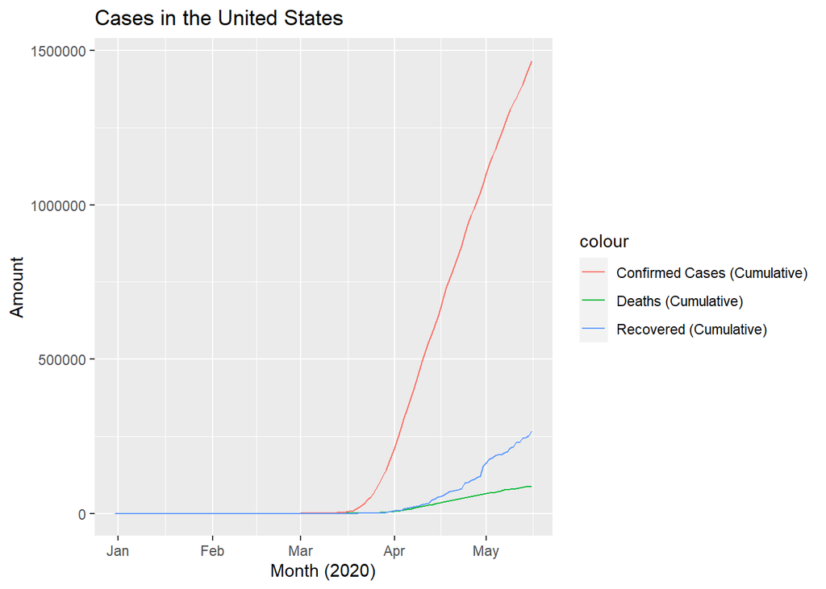

```r
US_data %>%
  ggplot(aes(Date)) +
  geom_line(aes(y=Confirmed, colour="Confirmed Cases (Cumulative)")) +
  geom_line(aes(y=Death, colour="Deaths (Cumulative)")) +
  geom_line(aes(y=Recovered, colour="Recovered (Cumulative)")) +
  labs(title="Cases in the United States", x="Month (2020)", y="Amount")
```

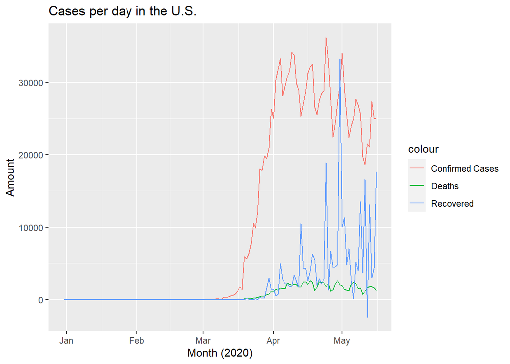

```r
US_data %>%
  ggplot(aes(Date)) +
  geom_line(aes(y=newConfirmed, colour="Confirmed Cases")) +
  geom_line(aes(y=newDeath, colour="Deaths")) +
  geom_line(aes(y=newRecovered, colour="Recovered")) +
  labs(title="Cases per day in the U.S.", x="Month (2020)", y="Amount")
```

We can see that starting from mid-March, there was a very steep increase in cases per day. Let’s filter the date to after March 15th using **filter** again so we can get a better view at the growth. In order to get a better picture after mid-March, we will once again graph the two respective graphs.

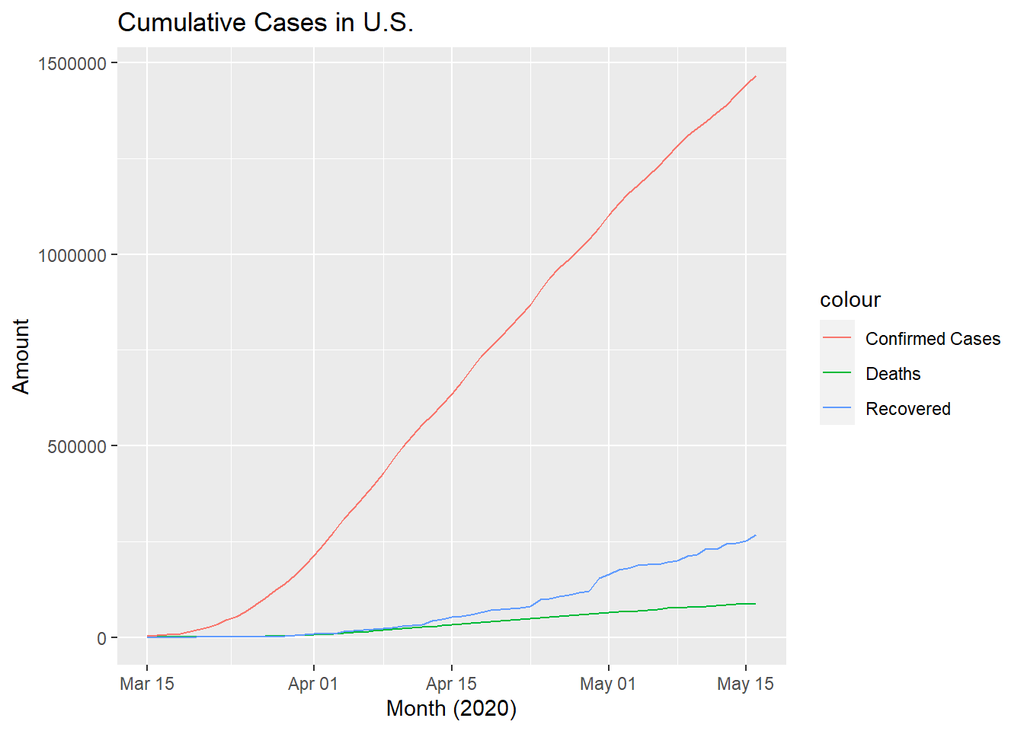

```r
US_data_filt <- filter(US_data, Date >= "2020-03-15")

US_data_filt %>%
  ggplot(aes(Date)) +
  geom_line(aes(y=Confirmed, colour="Confirmed Cases")) +
  geom_line(aes(y=Death, colour="Deaths")) +
  geom_line(aes(y=Recovered, colour="Recovered")) +
  labs(title="Cumulative Cases in U.S.", x="Month (2020)", y="Amount")
```

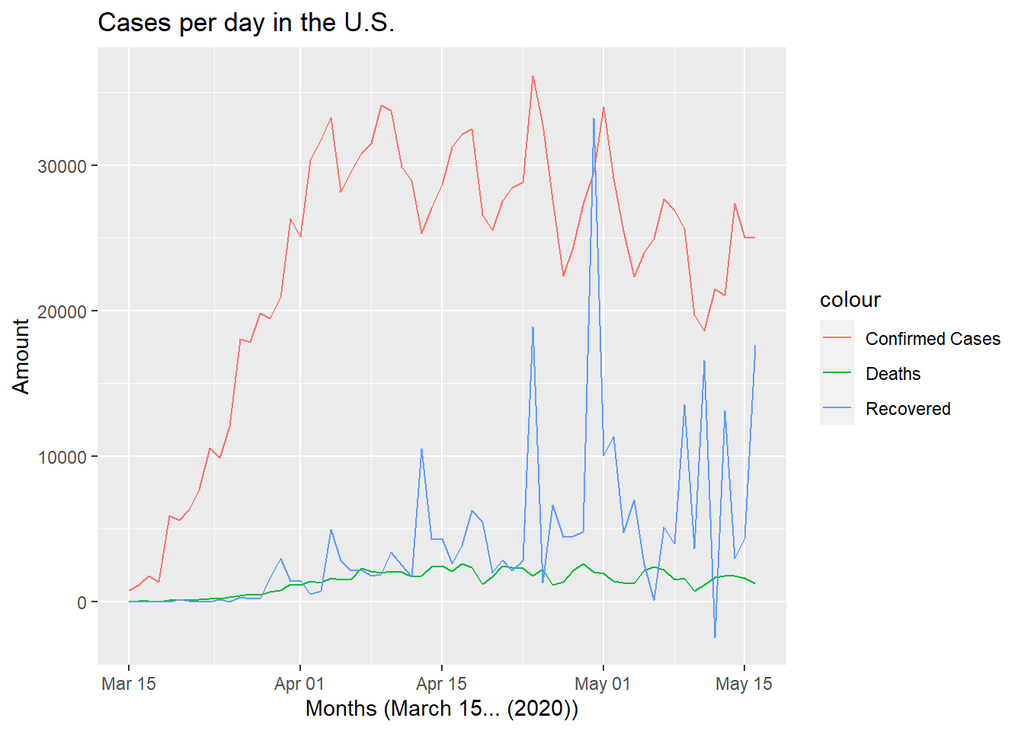

```r
US_data_filt %>%
  ggplot(aes(Date)) +
  geom_line(aes(y=newConfirmed, colour="Confirmed Cases")) +
  geom_line(aes(y=newDeath, colour="Deaths")) +
  geom_line(aes(y=newRecovered, colour="Recovered")) +
  labs(title="Cases per day in the U.S.", x="Months (March 15... (2020))", y="Amount")
```

### Additional dataset

In order to further analyze this, we decided to look at another dataset that focuses on Coronavirus statistics in the United States.

Dataset can be found at: https://www.kaggle.com/headsortails/covid19-us-county-jhu-data-demographics

There are many datasets available at this source but for this analysis we have chosen the **covid_us_county** dataset

The data is also fetched from John Hopkins University but focuses more on the cases for every state and county in the United States. We want to approach this by grouping the states together. We will then have another dataset that will increase the accuracy of our US analysis.

There are many different columns but we only be viewing these:

- state: Name of US State
- date: Reported date
- cases: Cumulative # cases
- deaths: Cumulative # deaths

```r
csv_file <- "covid_us_county.csv"
dataset2 <- read_csv(csv_file)
sample_n(dataset2, 10)
```

```
## # A tibble: 10 x 9
##     fips county       state           lat   long date    cases state_code deaths
##    <dbl> <chr>        <chr>         <dbl>  <dbl> <chr>   <dbl> <chr>       <dbl>
##  1 12013 Calhoun      Florida        30.4  -85.2 2/6/20      0 FL              0
##  2 12073 Leon         Florida        30.5  -84.3 1/22/20     0 FL              0
##  3 18171 Warren       Indiana        40.3  -87.4 4/17/20     5 IN              1
##  4 42055 Franklin     Pennsylvania   39.9  -77.7 4/17/20    89 PA              0
##  5 25005 Bristol      Massachusetts  41.8  -71.1 5/5/20   4235 MA            210
##  6    72 <NA>         Puerto Rico    18.2  -66.6 3/1/20      0 <NA>            0
##  7 48169 Garza        Texas          33.2 -101.  2/8/20      0 TX              0
##  8 19051 Davis        Iowa           40.7  -92.4 3/19/20     0 IA              0
##  9 34029 Ocean        New Jersey     39.9  -74.3 3/17/20     4 NJ              0
## 10 51143 Pittsylvania Virginia       36.8  -79.4 5/3/20     14 VA              1
```

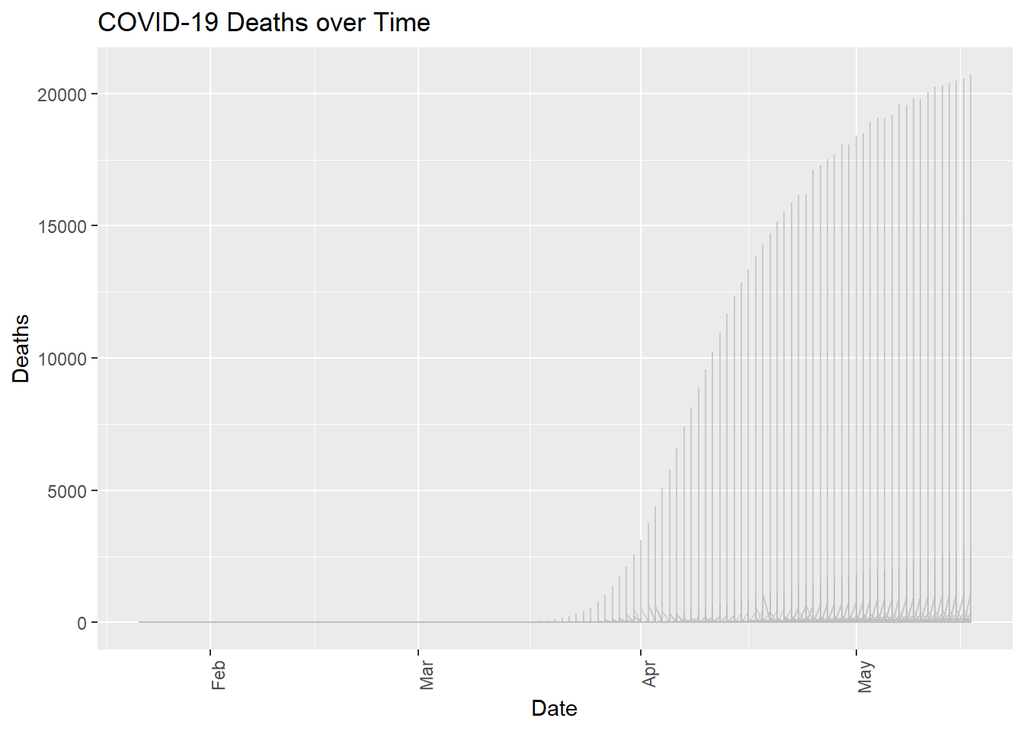

```r
plot_me <- dataset2 %>%
  select(state, date, deaths)  %>%
  mutate(date = paste(date, "20", sep="")) %>%
  mutate(date = as.Date(date, "%m/%d/%Y"))

plot_me %>%
  ggplot(aes(x=date,y=deaths,group=factor(state))) +
  geom_line(color="GRAY", alpha=3/4, size=1/2) +
  labs(title="COVID-19 Deaths over Time",
          x="Date", y="Deaths") +
  theme(axis.text.x = element_text(angle = 90, hjust = 1))
```

## 6. Analysis and Thoughts

With this data, we can see that in March, there was a large spike in confirmed COVID-19 cases. This was also around the time that severe restriction was enacted in the United States such as the Stay-at-Home order. One possible explanation for this could be that testing was increased as more testing kits became available around this time. Therefore, more confirmed cases could be recorded. However, some news outlets report that the United States was always slow with testing compared to other countries, and was slow to test in March as well. A limitation with this data is the contradicting information online. News media outlets are the public’s primary source for COVID-19 related information. Without consistent reports, it is difficult to gauge the true reason for the spike. https://www.washingtonpost.com/politics/2020/03/30/11-100000-what-went-wrong-with-coronavirus-testing-us/ Another reason for the spike could be the way COVID-19 positives and deaths are recorded. As of now, if an individual is experiencing any of the many symptoms of COVID-19 and goes to a primary care physician or hospital, they will be recorded as having COVID-19, even if they have the flu or the common cold. Those experiencing these symptoms but not actually infected with COVID-19 could contribute to the unusually large spike we see in the plot. Additionally, the COVID-19 test itself is not as accurate as the public may believe. The Abbott Coronavirus Test, which is the test most widely used, is known to skew towards false positives. Unfortunately, this also contributes to the spike in cases and decreases the accuracy in magnitude of the virus’s spread. https://abcnews.go.com/Health/accurate-us-coronavirus-death-count-experts-off-tens/story?id=70385359 https://www.medpagetoday.com/blogs/working-stiff/85925 https://www.npr.org/sections/coronavirus-live-updates/2020/05/14/856531970/fda-cautions-about-accuracy-of-widely-used-abbott-coronavirus-test False positives are particularly harmful to data collection because they contribute to the total number infected. The total number infected is used to calculate the CMR (crude mortality rate) and can affect the final publicized percentage.

“Flatten the Curve” has become almost a household phrase now, with social distancing becoming the primary way the government has tried to slow the rate of infection. Creating a downward trend in both the number of those infected and the mortality rate is extremely important; however, a counterargument to flattening the curve to slow the infection rate is that by social distancing we are preventing herd immunity. However, herd immunity with COVID-19 may not be feasible. With New York City as an example, 15-21% of people in New York City have been exposed to the virus as of the end of April, 2020. Of those infected, around 1 in 500 have died. This is not factoring any false calculations by the hospitals or by the media reporting the deaths. With this data, COVID-19 is much too lethal to rely on herd immunity. Therefore, the public should be concerned with contracting and spreading the virus, especially to those who are more vulnerable. In order to reduce the mortality rate in the future, flattening the curve will not only reduce the number of people infected at one time, but it will allow for more attention in medical facilities when the symptoms become serious. With increased attention from medical practitioners and those who are trained to deal with these situations, more people can have hope to recover. https://www.nytimes.com/article/flatten-curve-coronavirus.html https://coronavirus.jhu.edu/from-our-experts/early-herd-immunity-against-covid-19-a-dangerous-misconception

## 7. Linear Regression Model

```r
reg <- lm(Death~Date, data=US_data)
result <- reg %>% tidy()
result
```

```
## # A tibble: 2 x 5
##   term         estimate std.error statistic  p.value
##   <chr>           <dbl>     <dbl>     <dbl>    <dbl>
## 1 (Intercept) -9972029.  645419.      -15.5 9.98e-32
## 2 Date             545.      35.2      15.5 8.65e-32
```

```r
reg2 <- lm(Death~Date, data=US_data_filt)
result2 <- reg2 %>% tidy()
result2
```

```
## # A tibble: 2 x 5
##   term          estimate std.error statistic  p.value
##   <chr>            <dbl>     <dbl>     <dbl>    <dbl>
## 1 (Intercept) -30019478.  652838.      -46.0 4.69e-49
## 2 Date             1636.      35.5      46.0 4.36e-49
```